# Prelim Analysis/Data Inspection

Daniel Shephard, Jake Bowers, Michael DiDomenico

March 20, 2017

# Overview of the Project

## Goal:

Accelerate finding employment and reduce time on unemployment insurance among unemployment insurance clients in Oregon.

This file executes the analysis of the experiment. It relies on files produced by the `datasetup.Rmd` file.

The two working data files are produced by the `datasetup.Rmd` file.

## Table of welcome conversations by field office

The following table shows the number of welcome conversations conducted at each of the field offices in each month. Some of these welcomes come from the month by month data pulls. Others come from the updated wages file. The first column has the field office labels.

|  | March | April | May | June | July | August | September | October | November | December |
| --- | --- | --- | --- | --- | --- | --- | --- | --- | --- | --- |
| 102 | 730 | 665 | 645 | 712 | 710 | 711 | 644 | 699 | 692 | 743 |
| 150 | 62 | 49 | 48 | 43 | 58 | 64 | 58 | 98 | 131 | 164 |
| 180 | 631 | 556 | 547 | 642 | 584 | 659 | 518 | 624 | 643 | 693 |
| 210 | 581 | 602 | 576 | 652 | 669 | 650 | 553 | 609 | 696 | 927 |
| 250 | 87 | 59 | 70 | 95 | 85 | 89 | 106 | 106 | 140 | 168 |
| 270 | 204 | 192 | 227 | 250 | 262 | 286 | 193 | 240 | 279 | 336 |
| 310 | 693 | 567 | 674 | 778 | 744 | 737 | 652 | 705 | 853 | 949 |
| 320 | 200 | 212 | 171 | 230 | 229 | 289 | 185 | 216 | 283 | 313 |
| 710 | 156 | 110 | 125 | 150 | 150 | 138 | 148 | 183 | 264 | 296 |
| 724 | 258 | 169 | 147 | 172 | 179 | 166 | 173 | 229 | 319 | 575 |
| 810 | 71 | 64 | 64 | 77 | 80 | 73 | 79 | 84 | 152 | 214 |
| 811 | 105 | 85 | 95 | 122 | 107 | 98 | 69 | 122 | 199 | 240 |
| 820 | 94 | 66 | 38 | 56 | 67 | 49 | 55 | 57 | 125 | 190 |
| 920 | 35 | 21 | 22 | 21 | 24 | 29 | 21 | 31 | 50 | 76 |

# The Experiment:

The experiment randomly assigned the new set of procedures to 7 out of the 14 offices after first grouping the offices into pairs. Pairs were created by both urban, geography, size (number of people who came for UI), and quality of staff (judgement of the management in Oregon). Pairs provided by the management of the Oregon State program.

The number of welcomes and average weeks on UI is from 2015 data (Pre Intervention)

|  | fo.num | fo.name.x | treat | tot | ui.wks | pair |
| --- | --- | --- | --- | --- | --- | --- |
| 210 | 210 | Salem | 0 | 3157 | 16.09 | a |
| 310 | 310 | Eugene | 1 | 3803 | 15.82 | a |
| 820 | 820 | La Grande | 0 | 329 | 15.19 | b |
| 920 | 920 | Baker City | 1 | 154 | 15.62 | b |
| 250 | 250 | Newport | 0 | 327 | 16.38 | c |
| 150 | 150 | Astoria | 1 | 319 | 15.01 | c |
| 102 | 102 | Gresham | 0 | 3615 | 16.64 | d |
| 180 | 180 | Oregon City | 1 | 2897 | 16.61 | d |
| 270 | 270 | Albany | 0 | 1283 | 15.79 | e |
| 320 | 320 | Roseburg | 1 | 1209 | 15.52 | e |
| 724 | 724 | Redmond | 0 | 747 | 15.50 | f |
| 710 | 710 | Klamath Falls | 1 | 718 | 16.27 | f |
| 810 | 810 | Pendleton | 0 | 404 | 15.92 | g |
| 811 | 811 | Hermiston | 1 | 487 | 15.19 | g |

### Outcomes

The overall outcomes collected at the individual level within the period covered by the data pull included:

- `welcome` Whether the person had a welcome meeting
- `uiexit` Whether the person stopped making unemployment claims for 3 weeks in a row.
- `employed` Whether a different company reports wages for the person in a quarter after the quarter they applied for UI
- `time.to.exit` The number of days between making the first claim and exiting the program.
- `plans` Number of action plans uploaded by an individual in the program
- `wages` The wages earned by the person (?average? ?weekly?)

??Why is time.to.exit negative sometimes? (DS: What is the frequency of this? Are they only clustered at the very start of the trial? I could imagine this happening in the March group). And yes, the ‘time.to.exit’ should represent the number of days between the two dates. (PT: Negative times to exit occur in all months, and are always within 30 days, so perhaps an error in data entry?)

```
    welcome          uiexit         employed      time.to.exit       plans           wages
 Min.   :0.000   Min.   :0.000   Min.   :0.000   Min.   :-30.0   Min.   :0.000   Min.   :    5
 1st Qu.:0.000   1st Qu.:0.000   1st Qu.:0.000   1st Qu.: 25.0   1st Qu.:0.000   1st Qu.:  802
 Median :1.000   Median :1.000   Median :0.000   Median : 61.2   Median :0.000   Median : 2268
 Mean   :0.653   Mean   :0.574   Mean   :0.184   Mean   : 90.8   Mean   :0.293   Mean   : 3395
 3rd Qu.:1.000   3rd Qu.:1.000   3rd Qu.:0.000   3rd Qu.:145.2   3rd Qu.:1.000   3rd Qu.: 4572
 Max.   :1.000   Max.   :1.000   Max.   :1.000   Max.   :327.0   Max.   :4.000   Max.   :84670
                                                                                 NA's   :33686
```

```
    April August December July June March  May November October September
  0   744   1773     4088 1142  870  1251  725     3045    2165      1639
  1  2673   2265     1796 2806 3130  2656 2724     1781    1838      1815
```

## Employment Center Level Analysis

Because the intervention was randomized at the level of the employment office, we compare outcomes at that level: did offices in the new program display outcomes that differed from the offices operating under the status quo program?

|  | fonum | insert_mean | welcome_mean | uiexit_mean | employed_mean | time.to.exit_mean | plans_mean | wages_mean | missingwage | N | fo.num | fo.name.x | mar | apr | may | jun | jul | aug | tot | pair | fo.name.y | ui.wks | selected | treat | treatMD | welcomeMD | uiexitMD | employedMD | time.to.exitMD | … |
| --- | --- | --- | --- | --- | --- | --- | --- | --- | --- | --- | --- | --- | --- | --- | --- | --- | --- | --- | --- | --- | --- | --- | --- | --- | --- | --- | --- | --- | --- | --- |
| 210 | 210 | 0.0000 | 0.6984 | 0.5899 | 0.2020 | 90.96 | 0.0026 | 3129 | 5249 | 6515 | 210 | Salem | 540 | 504 | 433 | 607 | 611 | 462 | 3157 | a | SALEM | 16.09 | 0 | 0 | -0.5 | 0.0064 | 0.0050 | 0.0082 | -0.5840 | … |
| 310 | 310 | 0.8452 | 0.6857 | 0.5798 | 0.1855 | 92.13 | 0.6381 | 3225 | 6030 | 7352 | 310 | Eugene | 619 | 627 | 538 | 647 | 765 | 607 | 3803 | a | EUGENE | 15.82 | 1 | 1 | 0.5 | -0.0064 | -0.0050 | -0.0082 | 0.5840 | … |
| 820 | 820 | 0.0000 | 0.7604 | 0.4956 | 0.1443 | 85.41 | 0.0063 | 2885 | 690 | 797 | 820 | La Grande | 74 | 57 | 45 | 52 | 62 | 39 | 329 | b | LA GRANDE | 15.19 | 1 | 0 | -0.5 | 0.0484 | 0.0054 | -0.0006 | 1.2098 | … |
| 920 | 920 | 0.8273 | 0.6636 | 0.4848 | 0.1455 | 82.99 | 0.6364 | 2247 | 284 | 330 | 920 | Baker City | 44 | 22 | 20 | 32 | 22 | 14 | 154 | b | BAKER CIT | 15.62 | 0 | 1 | 0.5 | -0.0484 | -0.0054 | 0.0006 | -1.2098 | … |
| 250 | 250 | 0.0000 | 0.6119 | 0.5483 | 0.1542 | 83.60 | 0.0060 | 2812 | 855 | 1005 | 250 | Newport | 65 | 61 | 39 | 60 | 58 | 44 | 327 | c | NEWPORT | 16.38 | 0 | 0 | -0.5 | -0.0276 | 0.0083 | 0.0100 | 1.6653 | … |
| 150 | 150 | 0.8387 | 0.6671 | 0.5316 | 0.1342 | 80.27 | 0.6168 | 2861 | 681 | 775 | 150 | Astoria | 60 | 47 | 52 | 59 | 60 | 41 | 319 | c | ASTORIA | 15.01 | 1 | 1 | 0.5 | 0.0276 | -0.0083 | -0.0100 | -1.6653 | … |
| 102 | 102 | 0.0000 | 0.6026 | 0.5914 | 0.1944 | 96.94 | 0.0078 | 3654 | 5667 | 6951 | 102 | Gresham | 637 | 650 | 552 | 620 | 640 | 516 | 3615 | d | PORTLAND | 16.64 | 0 | 0 | -0.5 | -0.0083 | -0.0044 | -0.0051 | 1.3873 | … |
| 180 | 180 | 0.8473 | 0.6192 | 0.6003 | 0.2045 | 94.17 | 0.5152 | 4526 | 4897 | 6097 | 180 | Oregon City | 479 | 459 | 431 | 558 | 567 | 403 | 2897 | d | OREGON CI | 16.61 | 1 | 1 | 0.5 | 0.0083 | 0.0044 | 0.0051 | -1.3873 | … |
| 270 | 270 | 0.0000 | 0.6736 | 0.5703 | 0.1952 | 89.78 | 0.0089 | 3223 | 2001 | 2469 | 270 | Albany | 206 | 208 | 152 | 221 | 242 | 254 | 1283 | e | ALBANY | 15.79 | 1 | 0 | -0.5 | -0.0079 | -0.0016 | 0.0085 | -1.5624 | … |
| 320 | 320 | 0.8424 | 0.6894 | 0.5735 | 0.1783 | 92.90 | 0.6899 | 2515 | 1933 | 2328 | 320 | Roseburg | 185 | 186 | 155 | 188 | 249 | 246 | 1209 | e | ROSEBURG | 15.52 | 0 | 1 | 0.5 | 0.0079 | 0.0016 | -0.0085 | 1.5624 | … |
| 724 | 724 | 0.0000 | 0.5069 | 0.5170 | 0.1517 | 81.27 | 0.0008 | 3071 | 2039 | 2387 | 724 | Redmond | 121 | 137 | 91 | 110 | 167 | 121 | 747 | f | REDMOND | 15.50 | 1 | 0 | -0.5 | -0.1050 | -0.0078 | 0.0000 | -1.7587 | … |
| 710 | 710 | 0.8384 | 0.7169 | 0.5326 | 0.1517 | 84.79 | 0.5797 | 2575 | 1470 | 1720 | 710 | Klamath Falls | 141 | 102 | 94 | 123 | 139 | 119 | 718 | f | KLAMATH F | 16.27 | 1 | 1 | 0.5 | 0.1050 | 0.0078 | 0.0000 | 1.7587 | … |
| 810 | 810 | 0.0000 | 0.7119 | 0.5021 | 0.1367 | 80.97 | 0.0010 | 3080 | 832 | 958 | 810 | Pendleton | 71 | 71 | 56 | 73 | 80 | 53 | 404 | g | PENDLETON | 15.92 | 0 | 0 | -0.5 | 0.0311 | -0.0368 | -0.0109 | 0.1353 | … |
| 811 | 811 | 0.8221 | 0.6498 | 0.5757 | 0.1586 | 80.70 | 0.5974 | 2858 | 1058 | 1242 | 811 | Hermiston | 94 | 69 | 85 | 93 | 90 | 56 | 487 | g | HERMISTON | 15.19 | 0 | 1 | 0.5 | -0.0311 | 0.0368 | 0.0109 | -0.1353 | … |

# Office Level Effects

We present differences of means below — they are an unbiased estimator of the average treatment effect. To assess the amount of information we have against the null of no effects, we present the results of hypothesis tests. Because the sample size is so small, we use a randomization-based approach. In short, the intervention appeared effective at increasing the number of plans completed, but did not appear influence any of the remaining outcomes.

```
                   theITTS  theps
welcomeMD         0.017988 0.7080
uiexitMD          0.009115 0.6214
employedMD       -0.002881 0.6208
time.to.exitMD   -0.140684 0.9392
plansMD           0.605699 0.0170
wagesMD        -149.612271 0.5248
```

# Test the null of no effects for any outcome

```
Number of observations deleted due to missingness: 0
```

```
     welcome_mean       uiexit_mean     employed_mean time.to.exit_mean        wages_mean               NPC
           0.7188            0.6250            0.6250            0.9375            0.5312            0.9375
```

Here we see that the evidence against the null of no effects for any outcome has a p-value of roughly 0.9375. I also show the individual p-values here because they are exact (as compared to the approximate ones above). Here using the Student’s T test statistic.

# Dealing with Missing Wage Data

Below we present the main results for employment status and compare them to results that exclude cases with mising wage data or treat those cases as instances of unemployment. In all cases the effect of treatment is marginally negative and non-significant.

```
    FALSE  TRUE
  0     0 33378
  1  7240   308
```

```
[1] 0.4513
```

ITT for Treatment on Employment Status

|  | ITT | p-value |
| --- | --- | --- |
| Main Result | -0.0029 | 0.6208 |
| Removing Cases with Missing Wages | -0.0040 | 0.5430 |
| Recoding Missing Wages as Unemployed | -0.0041 | 0.5410 |

# Effects Excluding Those With a Short Time on the Program

A small portion of the cases appear to have “negative” times to exiting the program, (N=957 or 2.3 percent of cases)

Time to exiting the program is calculated by the subtracting participant’s initial unemployment claim date from the date they exited the unemployment insurance. An individual is considered to have exited the program after three weeks of not claiming benefits. Thus exit dates are always on Sundays when a new claim period begins, while initial claim date may be any day during the week. In fact nearly 87.6 percent of these cases have values implying exit dates within seven days of the claim process, suggesting most of the negative cases are due to disconnect between how claims are processed and exit times are calculated. Still, as a robustness check, we repeat the main analysis, removing participants with negative times to exit. The results are essentially unchanged.

```
               theITTS_noneg theps_noneg
welcomeMD           0.018493      0.6858
uiexitMD            0.009677      0.5932
employedMD         -0.002099      0.7520
time.to.exitMD     -0.233387      0.8296
plansMD             0.617432      0.0152
wagesMD          -143.680025      0.5422
```

# Effects on Those With More Time in the Program?

We might expect that the effects may be larger among individuals who have spent more time in the program. In particular since wages are reported quarterly, we now re-do the analysis on the subset of respondents with initial claims dates before June 30, 2016, (N=14773

```
[1] 14773
```

|  | fonum | insert_mean | welcome_mean | uiexit_mean | employed_mean | time.to.exit_mean | plans_mean | wages_mean | missingwage | N | fo.num | fo.name.x | mar | apr | may | jun | jul | aug | tot | pair | fo.name.y | ui.wks | selected | treat | treatMD | welcomeMD | uiexitMD | employedMD | time.to.exitMD | … |
| --- | --- | --- | --- | --- | --- | --- | --- | --- | --- | --- | --- | --- | --- | --- | --- | --- | --- | --- | --- | --- | --- | --- | --- | --- | --- | --- | --- | --- | --- | --- |
| 210 | 210 | 0.0000 | 0.7163 | 0.7740 | 0.3032 | 141.1 | 0.0025 | 2731 | 1698 | 2411 | 210 | Salem | 540 | 504 | 433 | 607 | 611 | 462 | 3157 | a | SALEM | 16.09 | 0 | 0 | -0.5 | 0.0020 | 0.0046 | 0.0207 | -0.3814 | … |
| 310 | 310 | 0.7201 | 0.7124 | 0.7647 | 0.2618 | 141.9 | 0.5903 | 3115 | 2013 | 2712 | 310 | Eugene | 619 | 627 | 538 | 647 | 765 | 607 | 3803 | a | EUGENE | 15.82 | 1 | 1 | 0.5 | -0.0020 | -0.0046 | -0.0207 | 0.3814 | … |
| 820 | 820 | 0.0000 | 0.7638 | 0.6614 | 0.2598 | 160.1 | 0.0118 | 2492 | 190 | 254 | 820 | La Grande | 74 | 57 | 45 | 52 | 62 | 39 | 329 | b | LA GRANDE | 15.19 | 1 | 0 | -0.5 | 0.0587 | -0.0279 | -0.0165 | 5.3041 | … |
| 920 | 920 | 0.6364 | 0.6465 | 0.7172 | 0.2929 | 149.5 | 0.5556 | 1820 | 71 | 99 | 920 | Baker City | 44 | 22 | 20 | 32 | 22 | 14 | 154 | b | BAKER CIT | 15.62 | 0 | 1 | 0.5 | -0.0587 | 0.0279 | 0.0165 | -5.3041 | … |
| 250 | 250 | 0.0000 | 0.6399 | 0.7395 | 0.2572 | 137.2 | 0.0064 | 2598 | 232 | 311 | 250 | Newport | 65 | 61 | 39 | 60 | 58 | 44 | 327 | c | NEWPORT | 16.38 | 0 | 0 | -0.5 | -0.0043 | 0.0183 | -0.0100 | -10.0400 | … |
| 150 | 150 | 0.7079 | 0.6485 | 0.7030 | 0.2772 | 157.2 | 0.5000 | 2749 | 149 | 202 | 150 | Astoria | 60 | 47 | 52 | 59 | 60 | 41 | 319 | c | ASTORIA | 15.01 | 1 | 1 | 0.5 | 0.0043 | -0.0183 | 0.0100 | 10.0400 | … |
| 102 | 102 | 0.0000 | 0.6101 | 0.7489 | 0.2892 | 144.8 | 0.0087 | 3339 | 1979 | 2752 | 102 | Gresham | 637 | 650 | 552 | 620 | 640 | 516 | 3615 | d | PORTLAND | 16.64 | 0 | 0 | -0.5 | -0.0064 | -0.0157 | 0.0013 | 1.9855 | … |
| 180 | 180 | 0.7155 | 0.6229 | 0.7803 | 0.2866 | 140.8 | 0.4722 | 4101 | 1708 | 2376 | 180 | Oregon City | 479 | 459 | 431 | 558 | 567 | 403 | 2897 | d | OREGON CI | 16.61 | 1 | 1 | 0.5 | 0.0064 | 0.0157 | -0.0013 | -1.9855 | … |
| 270 | 270 | 0.0000 | 0.7239 | 0.7549 | 0.2990 | 140.8 | 0.0115 | 3103 | 617 | 873 | 270 | Albany | 206 | 208 | 152 | 221 | 242 | 254 | 1283 | e | ALBANY | 15.79 | 1 | 0 | -0.5 | 0.0096 | 0.0090 | 0.0191 | -4.0401 | … |
| 320 | 320 | 0.7122 | 0.7048 | 0.7368 | 0.2608 | 148.8 | 0.6458 | 2154 | 608 | 813 | 320 | Roseburg | 185 | 186 | 155 | 188 | 249 | 246 | 1209 | e | ROSEBURG | 15.52 | 0 | 1 | 0.5 | -0.0096 | -0.0090 | -0.0191 | 4.0401 | … |
| 724 | 724 | 0.0000 | 0.4786 | 0.7265 | 0.2547 | 147.4 | 0.0013 | 2748 | 560 | 746 | 724 | Redmond | 121 | 137 | 91 | 110 | 167 | 121 | 747 | f | REDMOND | 15.50 | 1 | 0 | -0.5 | -0.1267 | -0.0147 | -0.0048 | 1.2937 | … |
| 710 | 710 | 0.6747 | 0.7320 | 0.7560 | 0.2643 | 144.9 | 0.5213 | 2452 | 402 | 541 | 710 | Klamath Falls | 141 | 102 | 94 | 123 | 139 | 119 | 718 | f | KLAMATH F | 16.27 | 1 | 1 | 0.5 | 0.1267 | 0.0147 | 0.0048 | -1.2937 | … |
| 810 | 810 | 0.0000 | 0.6993 | 0.7246 | 0.2391 | 147.0 | 0.0000 | 2855 | 210 | 276 | 810 | Pendleton | 71 | 71 | 56 | 73 | 80 | 53 | 404 | g | PENDLETON | 15.92 | 0 | 0 | -0.5 | 0.0192 | -0.0161 | -0.0193 | 2.5350 | … |
| 811 | 811 | 0.7101 | 0.6609 | 0.7568 | 0.2776 | 142.0 | 0.6216 | 2456 | 296 | 407 | 811 | Hermiston | 94 | 69 | 85 | 93 | 90 | 56 | 487 | g | HERMISTON | 15.19 | 0 | 1 | 0.5 | -0.0192 | 0.0161 | 0.0193 | -2.5350 | … |

Here are the estimated ITTs and p-values for the null of no effects among the group that had the most time in the program.

```
                  theITTS2 theps2
welcomeMD         0.013736 0.8846
uiexitMD          0.012123 0.3774
employedMD        0.002714 0.8258
time.to.exitMD    0.955210 0.8370
plansMD           0.552072 0.0156
wagesMD        -145.515675 0.5354
```

# Test the null of no effects for any outcome

```
Number of observations deleted due to missingness: 0
```

```
     welcome_mean       uiexit_mean     employed_mean time.to.exit_mean        wages_mean               NPC
           0.8906            0.3750            0.8281            0.8281            0.5312            0.9531
```

Here we see that the evidence against the null of no effects for any outcome with a p-value of roughly 0.9531. I also show the individual p-values here because they are exact (as compared to the approximate ones above). The test statistic used here, by default, is Student’s T.

## Separate Effects by Month

Below I show the estimated effects by month for each of the six outcomes.

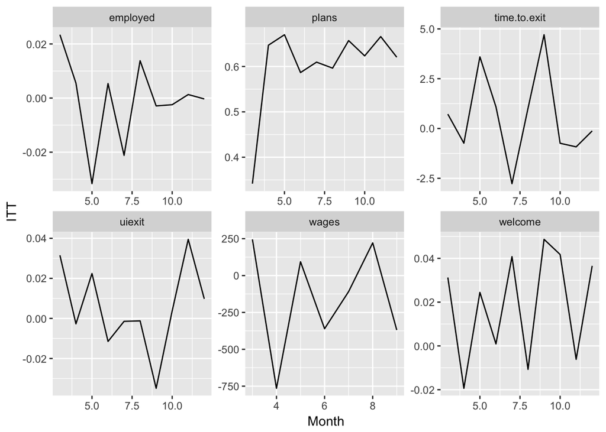